# tp_programacion_grupo15

Ge y Juan

TRABAJO PRACTICO 1 y sus correcciones (Junio 2023):

# Indice

## Análisis de la información del archivo Parque de la Memoria

## Introducción

Analizaremos datos correspondientes a personas desaparecidas en los Gobiernos de facto de la última dictadura militar entre los años 1969 y 1983. Dicha información fue colectada y publicada en una página web del Gobierno y fue procesada por Diego Koz.

## Exploración de los datos

```r
# Código para cargar o leer los datos

parque_memoria<-presentes::parque_de_la_memoria
```

```r
# nombres de las variables
names(parque_memoria)
```

```
##  [1] "id"                         "link"
##  [3] "nombre"                     "edad"
##  [5] "embarazada"                 "estado"
##  [7] "ano_en_monumento"           "domicilios"
##  [9] "estado_civil"               "estudios"
## [11] "fecha_de_nacimiento"        "fecha_de_secuestro"
## [13] "lugar_de_nacimiento"        "lugar_de_secuestro"
## [15] "nacionalidad"               "ocupaciones"
## [17] "sexo"                       "victimas_simultaneas"
## [19] "foto"                       "apodos"
## [21] "cantidad_de_hijos"          "victimas_relacionadas"
## [23] "casos_relacionados"         "militancia"
## [25] "articulos_periodisticos"    "datos_de_la_identificacion"
## [27] "fecha_de_asesinado"         "lugar_de_asesinato"
## [29] "observaciones"              "datos_familiares"
```

```r
#tipo de dato de las variables
#str(parque_memoria)

#ver cantidad de filas y columnas

nrow(parque_memoria)
```

```
## [1] 8751
```

```r
ncol(parque_memoria)
```

```
## [1] 30
```

## Análisis y selección

De la totalidad de la información, seleccionamos los siguientes datos:

1. Edad
2. Año en monumento
3. Sexo
4. Nacionalidad
5. Ocupaciones
6. Lugar de secuestro

```r
parque_memoria <-select(parque_de_la_memoria,"edad","ano_en_monumento","sexo","nacionalidad","ocupaciones","lugar_de_secuestro")
```

## Conocemos la cantidad de desaparecidos menores a 20 años de edad

```r
filter(parque_memoria,edad<20)|>
summarise(n = n())|>
knitr::kable(col.names = c ("Cantidad"))
```

| Cantidad |
| --- |
| 871 |

Como resultado del filtro aplicado, se puede constatar que la cantidad de desaparecidos menores a 20 años es de 871 personas.

## Detallamos la composición etária del grupo:

```r
parque_memoria|>
group_by(edad)|>
filter(edad %in% 1:19)|>
summarise(n = n())|>
knitr::kable(col.names = c ("Edad", "Cantidad"))
```

| Edad | Cantidad |
| --- | --- |
| 13 | 1 |
| 14 | 8 |
| 15 | 24 |
| 16 | 55 |
| 17 | 97 |
| 18 | 183 |
| 19 | 271 |
| 3 | 2 |
| 5 | 3 |
| 6 | 1 |
| 7 | 1 |
| 9 | 1 |

En la tabla se puede observar cómo está compuesto el grupo de desaparecidos menores a 20 años, pudiendose evidenciar que la edad de 19 años contó con mayor cantidad de desaparecidos (271), seguida por las edades de 18 (183) y 17 años (97) respectivamente.

```r
parque_memoria_menores20 <-filter(parque_memoria,edad<20)
```

## Conocemos las diez ocupaciones con mayor índice de desaparecidos

```r
parque_memoria|>
group_by(ocupaciones)|>
summarise(n = n())|>
arrange(desc(n), na.rm=TRUE)|>
filter(n %in% 577:41)|>
knitr::kable(col.names = c ("Ocupaciones", "Cantidad"))
```

| Ocupaciones | Cantidad |
| --- | --- |
| Estudiante Universitario | 577 |
| Estudiante Universitaria | 329 |
| Estudiante | 138 |
| Estudiante Secundario | 98 |
| Comerciante | 93 |
| Abogado | 63 |
| Albañil | 58 |
| Jornalero | 55 |
| Obrero | 51 |
| Obrero Metalúrgico | 41 |

Se puede constatar que el grupo de mayor cantidad de desaparecidos fueron aquellos que tenían como ocupación Estudiantes. Siendo que, los Estudiantes Universitarios (hombres y mujeres) ocuparon el primer lugar con un total de 906 desapariciones.

## Obtenemos la cantidad de monumentos que se incorporaron al Parque en el año 1977.

```r
filter(parque_memoria,ano_en_monumento==1977)|>
summarise(n = n())|>
knitr::kable(col.names = c ("Cantidad"))
```

| Cantidad |
| --- |
| 2827 |

Constatamos que la cantidad de monumentos de personas desaparecidas incorporadas en el año 1977 es de 2827.

## Calculamos la media y el desvio estandard de la edad de desaparecidos

En función de que la columna de edad no es un campo numérico sino de carácter (incluyendo valores nulos), se aplicó la siguiente fórmula, para crear una nueva columna denominada edad_numerico, conforme la devolución efectuada en el TP 1.

## Obtenemos ambos estadísticos:

```r
parque_memoria|>
mutate(edad_numerico=(as.numeric(edad)))|>
summarise(media_edad = mean(edad_numerico, na.rm = TRUE), desvio_st =sd(edad_numerico, na.rm = TRUE))|>
knitr::kable(col.names = c ("Promedio de edad de desaparecidos", "Dispersión"))
```

| Promedio de edad de desaparecidos | Dispersión |
| --- | --- |
| 28.47611 | 9.064539 |

Visualizamos que:

1. La edad media de desaparecidos ronda los 28 años y medio de edad.
2. Conforme el valor que representa el desvío estándar se puede observar una alta dispersión respecto de la media.

## Descubrimos la cantidad de incorporaciones de personas desaparecidas en el Parque de Monumento

```r
parque_memoria|>
mutate(ano_en_monumento =(as.numeric(ano_en_monumento)))|>
group_by(ano_en_monumento)|>
summarise(n = n())|>
knitr::kable(col.names = c ("Año en Monumento", "Cantidad"))
```

| Año en Monumento | Cantidad |
| --- | --- |
| 1969 | 8 |
| 1970 | 4 |
| 1971 | 24 |
| 1972 | 35 |
| 1973 | 57 |
| 1974 | 191 |
| 1975 | 756 |
| 1976 | 3845 |
| 1977 | 2827 |
| 1978 | 736 |
| 1979 | 134 |
| 1980 | 83 |
| 1981 | 26 |
| 1982 | 8 |
| 1983 | 12 |
| NA | 5 |

## Graficamos sus resultados:

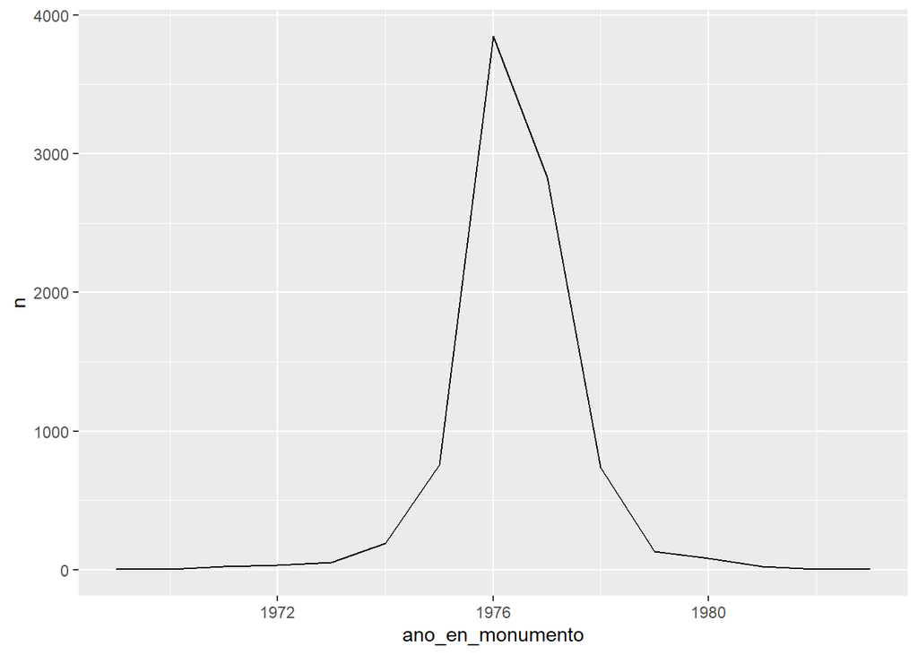

Evolución de las incorporaciones de desaparecidos al Parque de la Memoria a través de los años. Del gráfico puede observarse un crecimiento exponencial de incorporaciones de desaparecidos a partir del año 1969 y que llega a su valor máximo en el año 1976 (3845 personas).En adelante, se observa un decrecimiento abrupto de la curva.

```r
parque_memoria|>
mutate(ano_en_monumento =(as.numeric(ano_en_monumento)))|>
group_by(ano_en_monumento)|>
summarise(n = n())|>
ggplot(aes(ano_en_monumento, n))+
geom_line()
```

## Computamos la cantidad de hombres y mujeres desaparecidas

```r
parque_memoria|>
group_by(sexo)|>
summarise(n = n())|>
knitr::kable(col.names = c ("Sexo", "Cantidad"))
```

| Sexo | Cantidad |
| --- | --- |
| Femenino | 2230 |
| Masculino | 6519 |
| NA | 2 |

Se puede constatar que la mayor cantidad de desaparecidos fueron hombres (6519) respecto de las mujeres (2230).

## Conocemos las diferentes edades de los desaparecidos

```r
parque_memoria|>
group_by(edad)|>
summarise(n = n())|>
knitr::kable(col.names = c ("Edad", "Cantidad"))
```

| Edad | Cantidad |
| --- | --- |
| - | 232 |
| 13 | 1 |
| 14 | 8 |
| 15 | 24 |
| 16 | 55 |
| 17 | 97 |
| 18 | 183 |
| 19 | 271 |
| 20 | 396 |
| 21 | 537 |
| 22 | 614 |
| 23 | 581 |
| 24 | 613 |
| 25 | 537 |
| 26 | 524 |
| 27 | 514 |
| 28 | 438 |
| 29 | 367 |
| 3 | 2 |
| 30 | 298 |
| 31 | 275 |
| 32 | 237 |
| 33 | 226 |
| 34 | 169 |
| 35 | 144 |
| 36 | 126 |
| 37 | 119 |
| 38 | 115 |
| 39 | 95 |
| 40 | 83 |
| 41 | 84 |
| 42 | 56 |
| 43 | 66 |
| 44 | 50 |
| 45 | 63 |
| 46 | 48 |
| 47 | 43 |
| 48 | 43 |
| 49 | 37 |
| 5 | 3 |
| 50 | 48 |
| 51 | 42 |
| 52 | 23 |
| 53 | 27 |
| 54 | 28 |
| 55 | 26 |
| 56 | 26 |
| 57 | 20 |
| 58 | 16 |
| 59 | 17 |
| 6 | 1 |
| 60 | 17 |
| 61 | 20 |
| 62 | 9 |
| 63 | 13 |
| 64 | 10 |
| 65 | 8 |
| 66 | 4 |
| 67 | 9 |
| 68 | 1 |
| 69 | 3 |
| 7 | 1 |
| 70 | 1 |
| 71 | 1 |
| 72 | 1 |
| 73 | 1 |
| 76 | 2 |
| 77 | 1 |
| 9 | 1 |

Se puede concluir que la mayor cantidad de personas desaparecidas tenían la edad de 22 años (614 personas).

## Exploramos la cantidad de incorporaciones al Parque de Monumento en rango ascendente por año

```r
parque_memoria|>
group_by(ano_en_monumento)|>
summarise(n = n())|>
arrange(n)|>
knitr::kable(col.names = c ("Año en monumento", "Cantidad"))
```

| Año en monumento | Cantidad |
| --- | --- |
| 1970 | 4 |
| - | 5 |
| 1969 | 8 |
| 1982 | 8 |
| 1983 | 12 |
| 1971 | 24 |
| 1981 | 26 |
| 1972 | 35 |
| 1973 | 57 |
| 1980 | 83 |
| 1979 | 134 |
| 1974 | 191 |
| 1978 | 736 |
| 1975 | 756 |
| 1977 | 2827 |
| 1976 | 3845 |

## Descubrimos la cantidad de incorporaciones al Parque de Monumento en rango descendente por año

```r
parque_memoria|>
group_by(ano_en_monumento)|>
summarise(n = n())|>
arrange(desc(n))|>
knitr::kable(col.names = c ("Año en Monumento", "Cantidad"))
```

| Año en Monumento | Cantidad |
| --- | --- |
| 1976 | 3845 |
| 1977 | 2827 |
| 1975 | 756 |
| 1978 | 736 |
| 1974 | 191 |
| 1979 | 134 |
| 1980 | 83 |
| 1973 | 57 |
| 1972 | 35 |
| 1981 | 26 |
| 1971 | 24 |
| 1983 | 12 |
| 1969 | 8 |
| 1982 | 8 |
| - | 5 |
| 1970 | 4 |

De ambas tablas que anteceden, se desprende que la mayor cantidad de incorporaciones en el Parque de la Memoria se produce en el año 1976 con 3845 nombre de desaparecidos, mientras que el año con menor cantidad de incorporaciones fue en 1970 con la cantidad de 4.

TRABAJO PRACTICO 2

## **Hipótesis 1**:

Proponemos, cómo hipótesis, que la mayor cantidad de personas desaparecidas menores a 20 años fueron en su mayoría hombres

## Conocemos los datos:

```r
parque_memoria_menores20|>
  group_by(sexo) |>
 summarise(Cantidad = n())|>
 knitr::kable(col.names = c ("Sexo", "Cantidad"))
```

| Sexo | Cantidad |
| --- | --- |
| Femenino | 217 |
| Masculino | 653 |
| NA | 1 |

Concluimos que se corroboró la hipótesis, dado que los desaparecidos menores a 20 años son 653 masculinos mientras que las mujeres fueron 217.

## Graficamos su resultado:

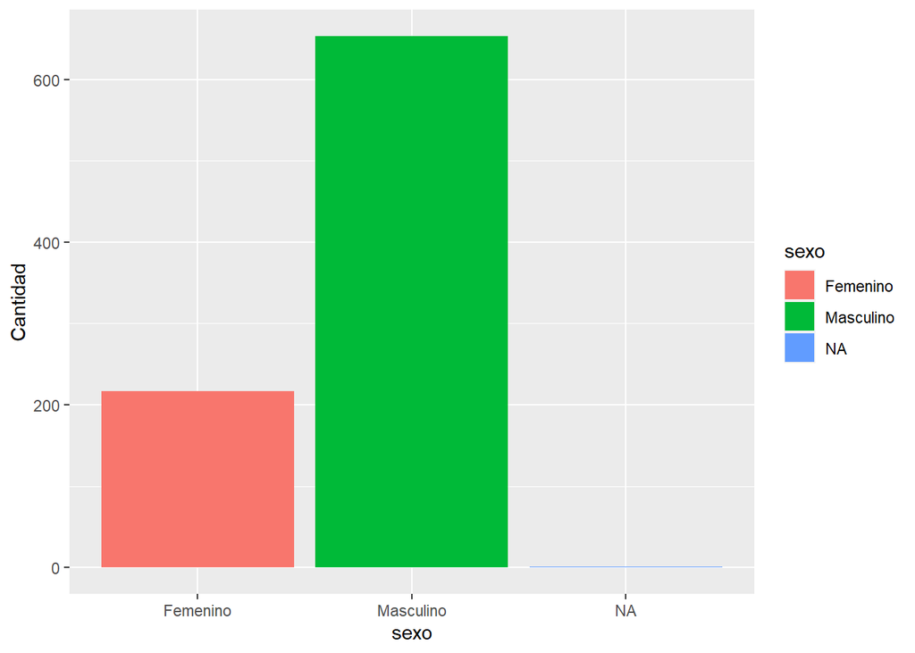

Observamos que la mayor cantidad de desaparecidos menores a 20 años resultan ser hombres

```r
parque_memoria_menores20|>
  group_by(sexo) |>
 summarise(Cantidad = n())|>
ggplot(aes(sexo, Cantidad, fill=sexo))+geom_col()
```

## **Hipótesis 2**:

Planteamos, como hipótesis, que la mayor cantidad de desaparecidos entre las ocupaciones Abogados, Estudiantes y Periodistas, fueron Abogados.

## Conocemos la cantidad de personas desaparecidas con esas ocupaciones

```r
parque_memoria|>
filter(ocupaciones %in% c("Abogado","Estudiante", "Periodista"))|>
group_by(ocupaciones)|>
summarise(Cantidad = n())|>
knitr::kable(col.names = c ("Ocupaciones", "Cantidad"))
```

| Ocupaciones | Cantidad |
| --- | --- |
| Abogado | 63 |
| Estudiante | 138 |
| Periodista | 21 |

Concluimos que la hipótesis planteada resultó errónea ya que la mayor cantidad de desparecidos tenían como ocupación “Estudiante” (138 desaparecidos).

## Gráficamos su resultado:

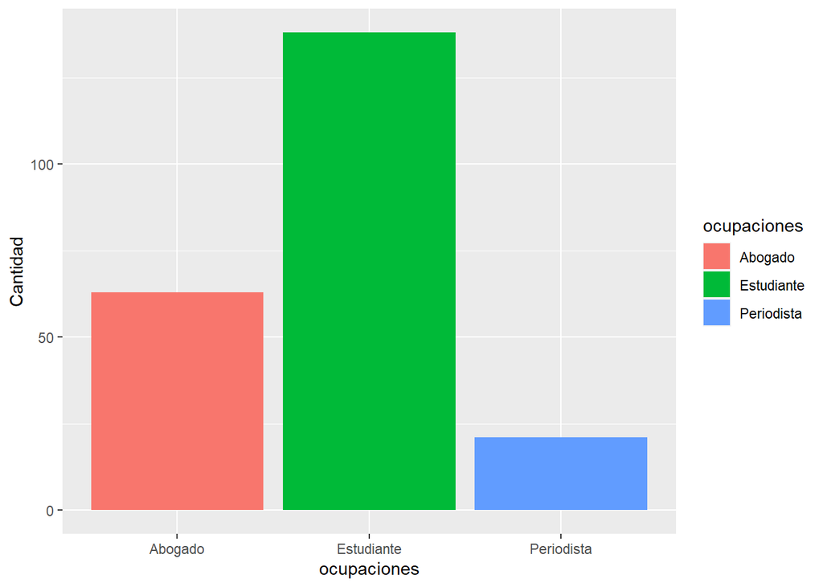

Observamos que la ocupación con mayor cantidad de personas desaparecidas fueron estudiantes

```r
parque_memoria|>
filter(ocupaciones %in% c("Abogado","Estudiante", "Periodista"))|>
group_by(ocupaciones)|>
summarise(Cantidad = n())|>
ggplot(aes(ocupaciones, Cantidad, fill=ocupaciones))+
geom_col()
```

## **Conclusión**:

Como resultado del análisis de los datos se puede evidenciar:

1. Que el promedio de edad de los desaparecidos es entre 28 y 29 años de edad; mientras que respecto de los menores a 20 años la cantidad de personas desaparecidas asciende a 871.
2. Que la mayor cantidad de desaparecidos tenía como ocupación Estudiante respecto a las ocupaciones Abogado y Periodista.
3. Que la mayor cantidad de desaparecidos fueron hombres.